# STA211 : détection des points atypiques via *Isolation Forest*

Vincent Audigier

10 avril, 2026

# 1 Contexte

La détection des points atypiques est une phase importante de la fouille. Du point de vue géométrique, il s’agit de points qui s’écartent “significativement” des autres. Ils sont, par définition, peu nombreux et localisés dans une zone peu dense du nuage de points. Leur détection est un enjeu car les analyses effectuées sur des échantillons contenant ces points peuvent conduire à des résultats très différents de ceux que l’on aurait obtenus sans ces points.

Il existe différentes techniques pour identifier les valeurs atypiques. L’objet de ce document est de présenter l’une d’entre elles, appelée *Isolation Forest* (Liu, Ting, and Zhou (2008)) qui est une méthode de référence en la matière et qui s’appuie sur les forêts aléatoires, présentées précédemment.

# 2 Principe

La détection se fait ici d’un point de vue complètement non-supervisé. Les forêts étant des méthodes supervisées, la construction des arbres y est différente. Le principe d’*Isolation Forest* est de construire des arbres **au hasard** qui vont fournir différents découpages de l’espace. Le postulat de départ est que les valeurs atypiques vont rapidement être isolées dans une région, contrairement aux autres observations qui seront isolées à un niveau plus profond de l’arbre. Ainsi, on va regarder à quelle profondeur de l’arbre une observation est isolée en moyenne. Ceci fournira un score par observation. Les différents scores devront alors être seuillés de façon à déterminer les valeurs atypiques des valeurs non-atypiques. Par la suite, nous revenons sur la construction des arbres, puis sur le calcul du score et enfin de son seuillage. La méthode sera ensuite appliquée sur les données German Crédit.

# 3 Construction des arbres au hasard

L’algorithme de construction d’un arbre est le suivant :

1. Sélectionner au hasard une variable
2. Choisir au hasard un point de coupure
3. Segmenter l’échantillon en deux sous-groupes
4. Répéter itérativement les étapes précédentes jusqu’à ce qu’un noeud :
1. ne contienne qu’un seul individu
2. atteigne une profondeur prédéfinie

La figure ci-dessous illustre cette procédure sur un exemple jouet bivarié.

[interactive chart not shown]

Figure 3.1: Algorithme de construction d’un arbre au hasard illustré en dimension 2. L’individu 1, situé dans une zone peu dense, y est rapidement isolé.

Pour construire une forêt, la procédure commence par un sous-échantillonnage afin de limiter ce que l’on appelle “l’effet de masque”. Ce phénomène correspond au fait que la procédure de détection doit elle-même faire face aux valeurs atypiques. Les valeurs atypiques peuvent en effet elles-mêmes avoir un impact sur la méthode de détection et ainsi *masquer* certaines d’entre elles. La Figure [3.2](https://par.moodle.lecnam.net/pluginfile.php/1819921/mod_label/intro/Cours_IF.html#fig:masking) illustre l’effet du sous-échantillonnage : on y voit des groupes de valeurs atypiques (en rouge). Isoler chacun de ces points via un arbre, tel que présenté précédemment, demanderait de nombreuses itérations et donc la profondeur des points associée serait grande. En tirant un sous-échantillon, ces points seront plus rapidement isolés et donc mieux détectés.

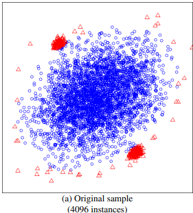

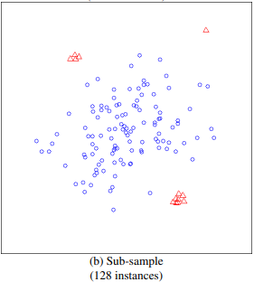

Figure 3.2: Illustration du sous-échantillonnage pour la détection d’anomalies. Source Liu, Ting, and Zhou (2008).

Une fois le sous-échantillonnage effectué, on construit un premier arbre au hasard, puis on recommence cette procédure $B$ fois de façon à obtenir une forêt de $B$ arbres.

# 4 Calcul du score

Etant donnée une observation $x$, on note $h(x)$ la longueur du chemin entre la racine et la feuille dans laquelle se situe l’observation $x$. Sur la base d’une forêt de $B$ arbres, on note $\bar{h}(x)$ la moyenne des longueurs des chemins pour l’observation $x$. Si $x$ est une valeur atypique, alors $\bar{h}(x)$ doit être petite.

Comme la profondeur d’un arbre est dépendante du nombre d’observations (plus le nombre d’observations est grand, plus l’arbre sera potentiellement profond), il est pertinent de relativiser $\bar{h}(x)$ à la profondeur moyenne attendue pour un échantillon de taille $n$. On note cette quantité $c(n)$:

$$c(n)=2\times H(n-1)-\frac{2(n-1)}{n}$$
avec $H(n-1)=\sum_{k=1}^{n-1} \frac{1}{k}$.

On définit alors le score de l’observation $x$ pour un échantillon de taille $n$ selon

$$s(x,n)=2^{-\frac{\bar{h}(x)}{c(n)}}$$

Si $\bar{h(x)}$ est petit devant $c(n)$ (ce qui correspond à un point atypique), alors $s(x,n)$ tend vers 1. A l’inverse si $\bar{h(x)}$ est grand devant $c(n)$ (ce qui correspond à un point dans une zone dense), alors $s(x,n)$ tend vers 0. Enfin, si $\bar{h(x)}$ est proche de $c(n)$, alors $s(x,n)$ est proche de 0.5

$s(x,n)$ peut être vu comme une standardisation de $\bar{h}(x)$ de façon à se ramener à l’intervalle $]0,1]$. Toutefois, il existe d’autres formes de standardisation (voir par exemple Rakotomalala (2026)).

# 5 Paramétrage

La méthode *Isolation Forest* dépend de trois paramètres : le nombre d’arbres, la taille des sous-échantillons et le seuil utilisé pour identifier les valeurs atypiques à partir des scores. Nous revenons sur ces points par la suite.

## 5.1 Nombres d’arbres

Le nombre d’arbres va avoir une incidence sur la variance des profondeurs moyennes $\bar{h}(x)$. Plus le nombre d’arbres sera grand, plus cette variance sera petite. Ainsi, les scores de chacune des observations seront plus fiables. En général, ce nombre est de l’ordre de la centaine, mais il peut se choisir en regardant l’évolution des scores en fonction du nombre d’arbres. On choisira un nombre assez grand pour que ces scores soient stabilisés.

## 5.2 Taille du sous-échantillon

Liu, Ting, and Zhou (2008) indiquent que tirer un sous-échantillon de 256 observations est suffisant et qu’il n’y a pas de gain substantiel à choisir un nombre plus élevé. Ceci permet notamment de réduire le coût computationnel. Les auteurs se basent pour cela sur une étude par simulation ayant une portée qui reste limitée. Toutefois, ce nombre est souvent repris dans la littérature.

## 5.3 Seuillage des scores

Une fois le score calculé pour chacune des observations, il convient de le seuiller de façon à déterminer quelles sont les observations atypiques et celles qui ne le sont pas. Il n’y a pas de valeur seuil universelle. Une façon de procéder consiste à observer la distribution des scores, puis à chercher un décrochage dans la distribution.

La figure suivante indique les scores calculés pour 100 arbres dans l’exemple précédent.

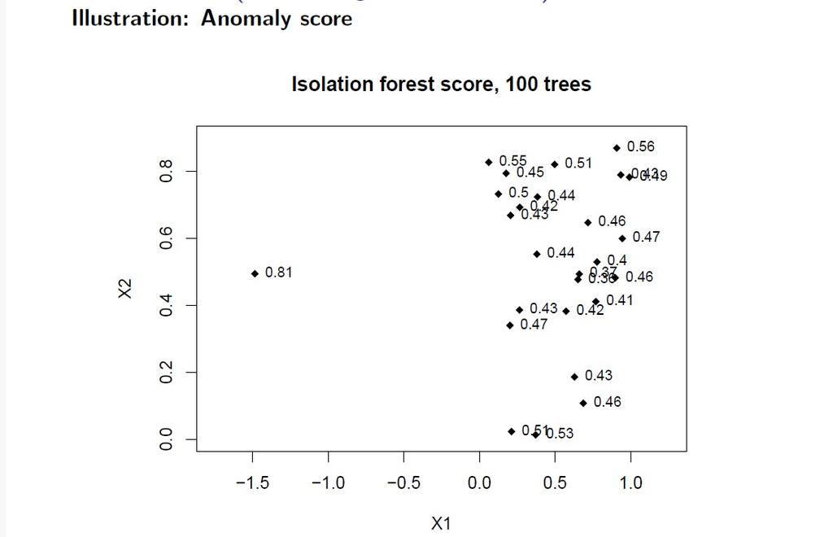

# 6 Application aux données German Credit

On retrouve dans le package isotree (Cortes (2026)) une implémentation de la méthode. Nous montrons comment celui-ci peut être utilisé sur les données German Crédit.

## 6.1 Chargement des librairies

```r
library(isotree)
library(FactoMineR)
```

## 6.2 Importation des données

```r
don <- read.table("https://archive.ics.uci.edu/ml/machine-learning-databases/statlog/german/german.data",
                  sep = " ",
                  stringsAsFactors = TRUE)
```

```r
# Modification des noms des variables
colnames(don)<-c(
  "Status",
  "Duration",
  "History",
  "Purpose",
  "Credit.Amount",
  "Savings account/bonds",
  "Length.of.current.employment",
  "Instalment.per.cent",
  "Sex.Marital.Status",
  "Guarantors",
  "Duration.in.Current.address",
  "Property",
  "Age.years",
  "Other.installment.plans",
  "Housing",
  "No.of.Credits.at.this.Bank",
  "Job",
  "No.of.dependents"
  ,"Telephone",
 "Foreign.Worker",
 "Creditability")


# Modification des noms des modalités des variables qualitatives
levels(don$Status) <- c("lt.0", "0.to.200", "gt.200", "none_status")

levels(don$History) <-
  c("noCredit.allPaid",
    "thisBank.AllPaid",
    "paidDuly",
    "delay",
    "critical")

levels(don$Purpose) <-
  c(
    "NewCar",
    "UsedCar",
    "Other",
    "Furniture.Equipment",
    "Radio.Television",
    "DomesticAppliance",
    "Repairs",
    "Education",
    "Retraining",
    "Business"
  )

levels(don$`Savings account/bonds`) <-
  c("lt.100", "100.to.500", "500.to.1000", "gt.1000", "Unknown_saving")

levels(don$Length.of.current.employment) <-
  c("lt.1", "1.to.4", "4.to.7", "gt.7", "Unemployed")

levels(don$Sex.Marital.Status) <-
  c(
    "Male.Divorced.Seperated",
    "Female.NotSingle",
    "Male.Single",
    "Male.Married.Widowed"
  )

levels(don$Guarantors) <- c("None_Guarantor", "CoApplicant", "Guarantor")

levels(don$Property) <-
  c("RealEstate", "Insurance", "CarOther", "Unknown_property")

levels(don$Other.installment.plans) <- c("Bank", "Stores", "None_other_installement")

levels(don$Housing) <- c("Rent", "Own", "ForFree")

levels(don$Job) <-
  c(
    "UnemployedUnskilled",
    "UnskilledResident",
    "SkilledEmployee",
    "Management.SelfEmp.HighlyQualified"
  )

levels(don$Foreign.Worker) <- c("yes_foreign", "no_foreign")

levels(don$Telephone) <- c("none_tel", "yes_tel")

# Codage des variables quantitatives en type "numeric" (plutot que "integer")

## pour la variable Duration
don$Duration <- as.numeric(don$Duration)
class(don$Duration)

## pour les variables Credits.Amount et Age.years
don$Credit.Amount <- as.numeric(don$Credit.Amount)
don$Age.years <- as.numeric(don$Age.years)

# Codage de la variable réponse en type "factor"
don$Creditability <- as.factor(don[, "Creditability"])
levels(don$Creditability) <- c("good", "bad")
```

## 6.3 Mise en oeuvre

On applique *Isolation Forest* avec 300 arbres et un sous-échantillon de taille 256.

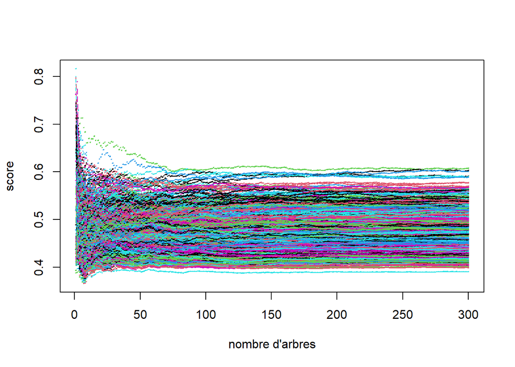

```r
set.seed(1234)      # graine du générateur aléatoire
ntree <- 300        # nombre d'arbres
sample_size <- 256  # taille du sous-échantillon

model <- isolation.forest(don,
                          sample_size = sample_size,
                          ntrees = ntree
                          )

# choix du nombre d'arbres

subscores <- sapply(seq.int(ntree),
                    FUN = function(nbtree, model, don){
                      submodel <- isotree.subset.trees(model, trees_take = seq.int(nbtree))
                      res.out <- predict.isolation_forest(submodel, newdata = don)
                      return(res.out)
                    },model = model, don = don)

matplot(t(subscores), type = "b", pch = 14, cex = .1,ylab = "score", xlab = "nombre d'arbres")
```

On constate que les valeurs des scores se stabilisent à partir de 100 arbres. Le choix de 300 arbres est donc tout à fait satisfaisant. On détermine ensuite un seuil pour déterminer les valeurs atypiques.

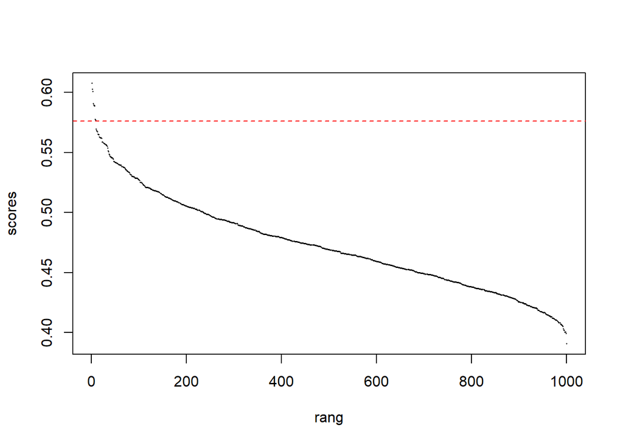

```r
# calcul du score pour chaque observation
scores <- predict.isolation_forest(model, newdata = don)
scores <- sort(scores, decreasing = TRUE)

# identification d'un seuil
plot(scores, type = "b", pch = 16, cex = 0.2, xlab = "rang")
threshold <- 0.576
abline(h = threshold, col = "red", lty = 2)
```

```r
#identification des valeurs les plus atypiques
names(which(scores>threshold))
```

```
## [1] "375" "757" "916" "187" "851" "227" "928" "890" "614"
```

On notera qu’on obtient sensiblement les mêmes valeurs sans tirer de sous-échantillon (pour cela, spécifier `sample_size = nrow(don)`).

La méthode *Isolation Forest* ne fait que fournir un score par observation sur la base de l’ensemble des variables, sans information sur les variables expliquant ce caractère atypique. Les caractéristiques de ces individus atypiques pourront, par exemple, être analysées à l’aide d’une analyse factorielle.

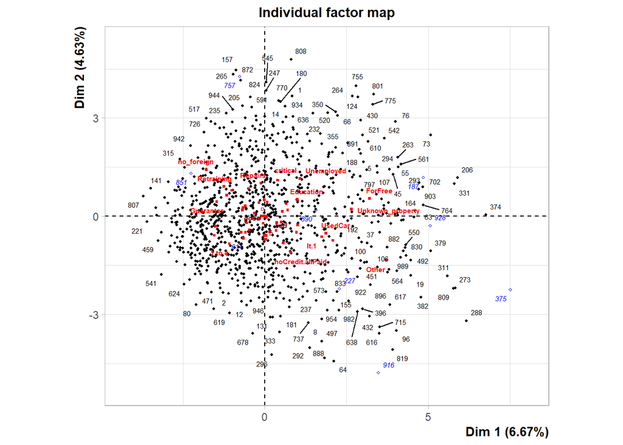

```r
res.FAMD <- FAMD(don,
                 ind.sup = as.numeric(names(which(scores>threshold))),
                 sup.var = which(colnames(don)=="Creditability"),
                 graph = FALSE)
plot(res.FAMD, choix="ind", cex=.5)
```

Il s’agira ensuite d’identifier les variables contribuant à la construction des axes sur lesquels ces observations ont des coordonnées élevées.

# 7 Conclusion

*Isolation Forest* est une méthode de référence pour la détection des valeurs atypiques. Elle a un faible coût algorithmique, ce qui lui permet de traiter des échantillons de grande taille. Elle n’est par ailleurs pas sensible aux problèmes d’échelle et ne nécessite donc pas de standardisation (ce qui est un point difficile quand l’échantillon contient des valeurs atypiques en raison de l’effet de masque). Nous avons ici présenté la méthode à partir d’exemples jouets contenant uniquement des variables quantitatives, mais l’extension à des données mixtes est directe, telle qu’illustrée sur le jeu German Credit.

Une fois les points atypiques identifiés, s’il y en a, il conviendra de les gérer. On pourra pour cela soit utiliser des méthodes d’analyse dites *robustes*, c’est-à-dire qui s’accommodent des valeurs atypiques, soit utiliser des stratégies de prétraitement. Dans ce dernier cas, il sera nécessaire de mener des analyses exploratoires pour identifier les variables à l’origine du caractère atypique d’une observation. Une fois ces variables identifiées, on pourra par exemple remplacer les valeurs jugées atypiques par des valeurs manquantes puis effectuer une imputation.

On retrouvera dans le package isotree (Cortes (2026)) différentes extensions de la méthode, notamment la possibilité d’effectuer une segmentation à chaque noeud selon des combinaison de variables, plutôt que selon une variable unique.

# Reférences

Cortes, David. 2026. *Isotree: Isolation-Based Outlier Detection*. https://doi.org/10.32614/CRAN.package.isotree.

Liu, Fei Tony, Kai Ming Ting, and Zhi-Hua Zhou. 2008. “Isolation Forest.” In *ICDM*, 413–22. IEEE Computer Society.

Rakotomalala, R. 2026. “Détection Des Anomalies : Isolation Forest.” https://eric.univ-lyon2.fr/ricco/cours/slides/isolation_forest.pdf.